# Getting started with micropubr

`micropubr` turns a `phyloseq` object into a publication-ready figure with a single, consistent call. Every function returns a `ggplot2` object, so you can always extend the result with `+`.

```r
library(micropubr)
data(GlobalPatterns, package = "phyloseq")

# Work with a lightly filtered subset for speed.
gp <- phyloseq::prune_taxa(
  phyloseq::taxa_sums(GlobalPatterns) > 5, GlobalPatterns)
```

## Alpha diversity

`mp_alpha()` computes within-sample diversity and, when a grouping variable is supplied, adds the appropriate statistical test automatically.

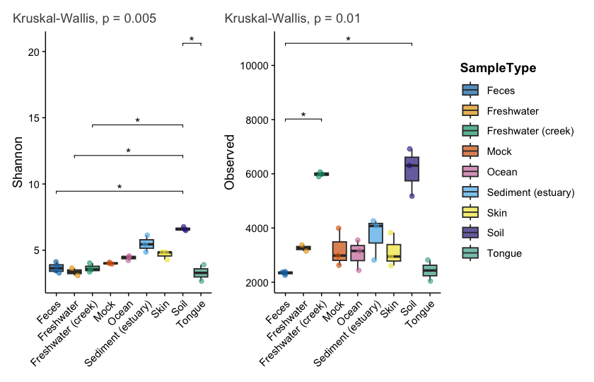

```r
mp_alpha(gp, measure = c("Shannon", "Observed"),
         group.by = "SampleType", test = "kruskal")
```

Switch to violins, or draw rarefaction curves, with `plot.type`:

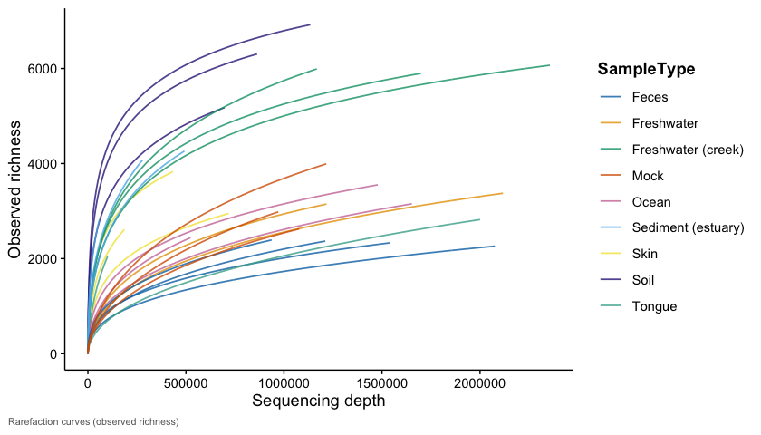

```r
mp_alpha(gp, plot.type = "rarefaction", group.by = "SampleType")
```

## Beta diversity

`mp_ordination()` computes the distance, runs the ordination, draws group ellipses, and reports a PERMANOVA in the caption — all by default.

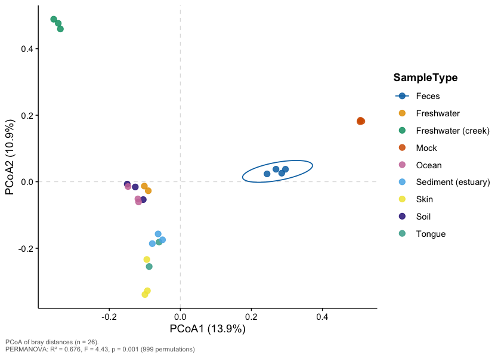

```r
mp_ordination(gp, method = "PCoA", distance = "bray", group.by = "SampleType")
```

The compositional (Aitchison) workflow is one argument away:

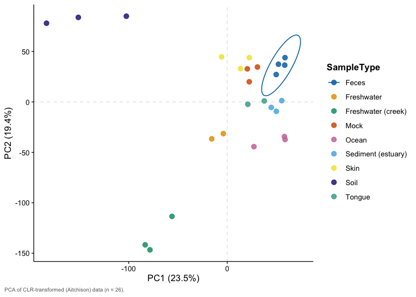

```r
mp_ordination(gp, method = "PCA", group.by = "SampleType")
```

## Taxonomic composition

`mp_taxa()` shows the top taxa at any rank and collapses the rest into “Other”.

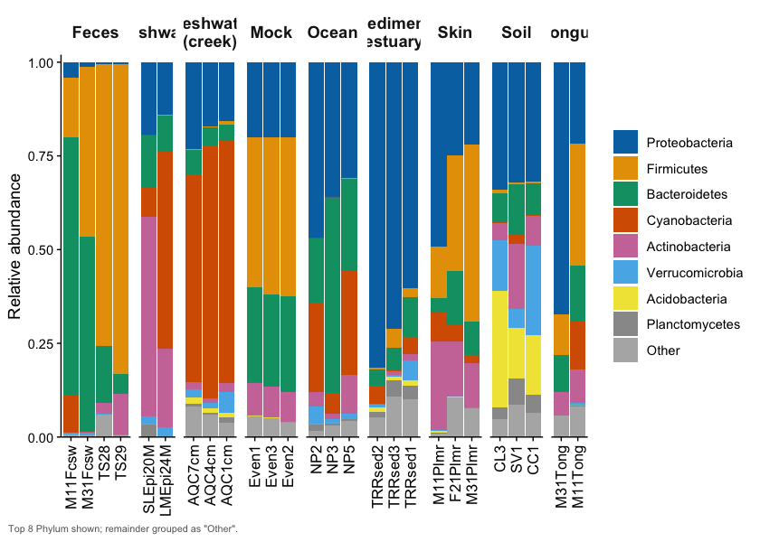

```r
mp_taxa(gp, tax.level = "Phylum", group.by = "SampleType", top.n = 8)
```

## Differential abundance

`mp_diff()` visualises results from `DESeq2`, `ALDEx2`, `ANCOM-BC` or any generic data frame. Here is a volcano plot from a generic table:

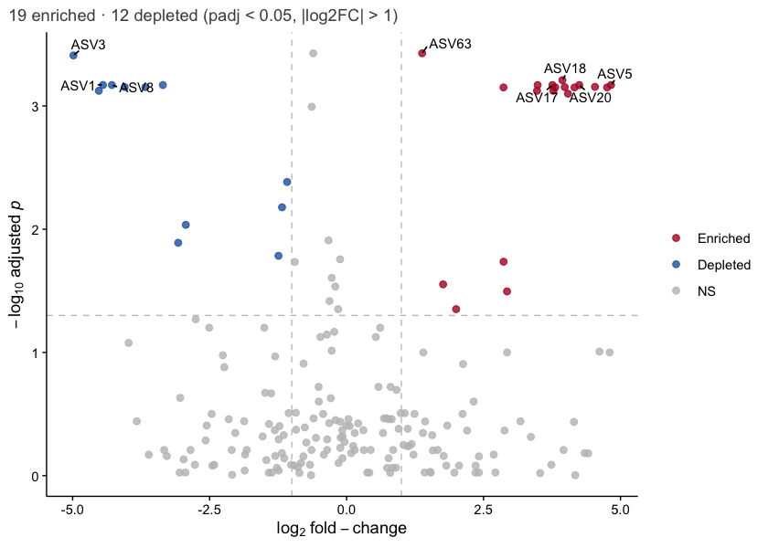

```r
set.seed(1)
res <- data.frame(
  feature = paste0("ASV", 1:200),
  log2FC  = rnorm(200, 0, 2),
  pvalue  = runif(200)^2
)
res$log2FC[1:20] <- rnorm(20, 4, 0.5) * sample(c(-1, 1), 20, TRUE)
res$pvalue[1:20] <- runif(20, 1e-9, 1e-4)
res$padj <- p.adjust(res$pvalue, "BH")

mp_diff(res, plot.type = "volcano", label.top = 8)
```

## Composing and exporting figures

Combine panels into a labelled multi-panel figure and export it at a journal column width.

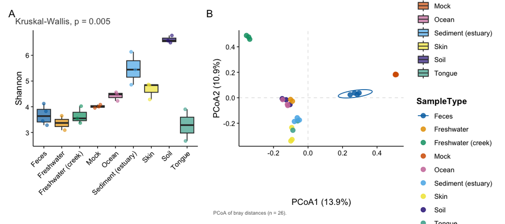

```r
fig <- mp_combine(
  mp_alpha(gp, measure = "Shannon", group.by = "SampleType"),
  mp_ordination(gp, group.by = "SampleType", permanova = FALSE),
  ncol = 2, tag.levels = "A"
)
fig
```

```r
mp_export(fig, "figure1.pdf", column = "double", dpi = 600)
```

## Theming and palettes

All functions accept a `theme` and `palette` argument. The defaults are colourblind-safe, but you can swap them freely:

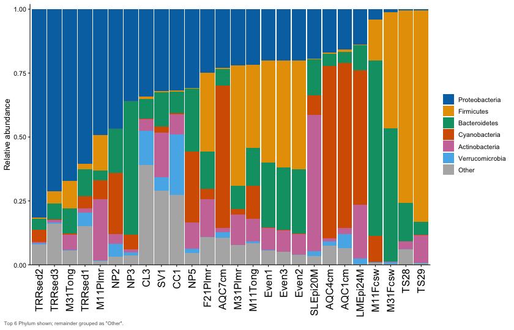

```r
mp_taxa(gp, tax.level = "Phylum", top.n = 6,
        palette = "taxa20", theme = mp_theme_nature())
```

See `?mp_palette` and the `mp_theme_*()` family for the full set.

## Interactive plots

Add `interactive = TRUE` to any plotting function to get a live [`plotly`](https://plotly.com/r/) widget instead of a static `ggplot` — hover for tooltips, zoom, and toggle groups via the legend. The figure below is interactive when the `plotly` package is installed:

```r
mp_ordination(gp, method = "PCoA", distance = "bray",
              group.by = "SampleType", interactive = TRUE)
```

[interactive chart not shown]

Interactive figures save to a self-contained web page via the same `mp_export()`, using an `.html` filename:

```r
w <- mp_alpha(gp, measure = "Shannon", group.by = "SampleType",
              interactive = TRUE)
mp_export(w, "alpha.html")
```

The visualization gallery vignette has more interactive examples. Note that `plotly` cannot reproduce a few static-only overlays (such as significance brackets), and the circular `mp_chord()` / `mp_circos()` figures have no interactive mode.